# 05 - Artificial cell mixtures

In this script, artificial cell mixtures will be constructed in silico by mixing together the DNAm-profiles of sorted blood cell types (downloaded from GSE167998) in several compositions. We start by making a baseline sample with the same blood cell composition as the average sample from our study, then make new artificial mixtures by adding 1 SD of one cell type while proportionally shrinking all others.

# Download data

Download the external dataset from GEO. For the sample sheet, the SuperSeries of GSE167998 will be used, which is GSE181034. However, since this Superseries does not contain complete DNAm-values, these were downloadeed separately from GSE167998 (GSE167998_matrix_processed.txt.gz, found [here](https://www.ncbi.nlm.nih.gov/geo/query/acc.cgi?acc=GSE167998)).

*NB: This code is not knit for computational time reasons. It has previously been run in RStudio. Its output will be loaded in the next chunk.*

```r
setwd("/exports/molepi/RSC_BIOS/Users/tjonkman/cellcounts")
.libPaths("/exports/molepi/RSC_BIOS/Users/tjonkman/Packages/4.3.1")

library(GEOquery)
#load series and platform data from GEO.
gset <- getGEO("GSE181034", GSEMatrix =TRUE, getGPL=FALSE)

#Extract the sample sheet and the DNAm-matrix from the gset.
salas.ss <- pData(gset[[1]])
salas.dnam <- exprs(gset[[1]])

#Save data.
save(salas.dnam, salas.ss, file = "05_salas data.rda")
```

# Select sorted blood cells

The external GEO-dataset contains 56 sorted blood cell samples in which DNAm has been measured. It also contains 12 mixed samples. Here, the 56 sorted blood cell samples will be selected. From those, the artificial blood cell compositions will be made.

```r
setwd("/exports/molepi/RSC_BIOS/Users/tjonkman/cellcounts")
.libPaths("/exports/molepi/RSC_BIOS/Users/tjonkman/Packages/4.3.1")

load("05_salas data.rda")
head(salas.ss)
```

```
##                title geo_accession                status submission_date
## GSM5121357  mem mix5    GSM5121357 Public on Feb 07 2022     Mar 01 2021
## GSM5121358 mem mix10    GSM5121358 Public on Feb 07 2022     Mar 01 2021
## GSM5121359 mem mix14    GSM5121359 Public on Feb 07 2022     Mar 01 2021
## GSM5121360  mem mix9    GSM5121360 Public on Feb 07 2022     Mar 01 2021
## GSM5121361 mem mix13    GSM5121361 Public on Feb 07 2022     Mar 01 2021
## GSM5121362  mem mix7    GSM5121362 Public on Feb 07 2022     Mar 01 2021
##            last_update_date    type channel_count
## GSM5121357      Feb 08 2022 genomic             1
## GSM5121358      Feb 08 2022 genomic             1
## GSM5121359      Feb 08 2022 genomic             1
## GSM5121360      Feb 08 2022 genomic             1
## GSM5121361      Feb 08 2022 genomic             1
## GSM5121362      Feb 08 2022 genomic             1
##                                      source_name_ch1 organism_ch1
## GSM5121357 artificial mixture of purified leukocytes Homo sapiens
## GSM5121358 artificial mixture of purified leukocytes Homo sapiens
## GSM5121359 artificial mixture of purified leukocytes Homo sapiens
## GSM5121360 artificial mixture of purified leukocytes Homo sapiens
## GSM5121361 artificial mixture of purified leukocytes Homo sapiens
## GSM5121362 artificial mixture of purified leukocytes Homo sapiens
##            characteristics_ch1 characteristics_ch1.1 characteristics_ch1.2
## GSM5121357    sample_plate: NA               age: NA       horvath_age: NA
## GSM5121358    sample_plate: NA               age: NA       horvath_age: NA
## GSM5121359    sample_plate: NA               age: NA       horvath_age: NA
## GSM5121360    sample_plate: NA               age: NA       horvath_age: NA
## GSM5121361    sample_plate: NA               age: NA       horvath_age: NA
## GSM5121362    sample_plate: NA               age: NA       horvath_age: NA
##            characteristics_ch1.3 characteristics_ch1.4 characteristics_ch1.5
## GSM5121357              mage: NA            purity: NA       meth_purity: NA
## GSM5121358              mage: NA            purity: NA       meth_purity: NA
## GSM5121359              mage: NA            purity: NA       meth_purity: NA
## GSM5121360              mage: NA            purity: NA       meth_purity: NA
## GSM5121361              mage: NA            purity: NA       meth_purity: NA
## GSM5121362              mage: NA            purity: NA       meth_purity: NA
##            characteristics_ch1.6 characteristics_ch1.7 characteristics_ch1.8
## GSM5121357    ethnicity_wide: NA       ethnic_self: NA    meth_ethnicity: NA
## GSM5121358    ethnicity_wide: NA       ethnic_self: NA    meth_ethnicity: NA
## GSM5121359    ethnicity_wide: NA       ethnic_self: NA    meth_ethnicity: NA
## GSM5121360    ethnicity_wide: NA       ethnic_self: NA    meth_ethnicity: NA
```

[output cut: 253 more lines]

```
## GSM5121362         <NA>         NA               NA    <NA>  2.04E+11
##            smoker:ch1 smp_type:ch1 time.point:ch1 tissue:ch1 treg:ch1
## GSM5121357         NA           NA           <NA>       <NA>        0
## GSM5121358         NA           NA           <NA>       <NA>    0.125
## GSM5121359         NA           NA           <NA>       <NA>    0.101
## GSM5121360         NA           NA           <NA>       <NA>     0.16
## GSM5121361         NA           NA           <NA>       <NA>    0.152
## GSM5121362         NA           NA           <NA>       <NA>     0.06
##            weight_kg:ch1
## GSM5121357            NA
## GSM5121358            NA
## GSM5121359            NA
## GSM5121360            NA
## GSM5121361            NA
## GSM5121362            NA
```

```r
dim(salas.ss)
```

```
## [1] 168 132
```

```r
#Select only the sorted cell types, and only the informative variables.
salas.ss <- salas.ss[-(grep(pattern = "Glioma", x = salas.ss$source_name_ch1)),]
salas.ss <- salas.ss[-(grep(pattern = "mixture", x = salas.ss$source_name_ch1)),]
salas.ss <- salas.ss[,c(1, 2, 8, 11, 17, 19, 20, 83)]

#Reformat data.
salas.ss$age <- do.call("rbind", strsplit(x = salas.ss$characteristics_ch1.1, split = "age: "))[,2]
salas.ss$race <- do.call("rbind", strsplit(x = salas.ss$characteristics_ch1.7, split = "ethnic_self: "))[,2]
salas.ss$weight <- do.call("rbind", strsplit(x = salas.ss$characteristics_ch1.9, split = "weight_kg: "))[,2]
salas.ss$height <- do.call("rbind", strsplit(x = salas.ss$characteristics_ch1.10, split = "height_cm: "))[,2]
salas.ss$basename <- do.call("rbind", strsplit(x = salas.ss$"basename:ch1", split = "/"))[,7]

#Relabel cell types. Use both an abbreviated name and a full name.
salas.ss <- salas.ss[order(salas.ss$source_name_ch1),]
salas.ss$ct <- c(rep("Mono", 5),
           rep("Eos", 4),
           rep("Treg", 3),
           rep("CD4Tnv", 5),
           rep("CD4Tmem", 4),
           rep("NK", 4),
           rep("CD8Tnv", 5),
           rep("CD8Tmem", 4),
           rep("Baso", 6),
           rep("Neu", 6),
           rep("Bnv", 4),
           rep("Bmem", 6)
           )

salas.ss$cell.type <- c(rep("Monocytes", 5),
                  rep("Eosinophils", 4),
                  rep("Regulatory T cells", 3),
                  rep("Naive CD4 T cells", 5),
                  rep("Memory CD4 T cells", 4),
                  rep("Natural Killer cells", 4),
                  rep("Naive CD8 T cells", 5),
                  rep("Memory CD8 T cells", 4),
                  rep("Basophils", 6),
                  rep("Neutrophils", 6),
                  rep("Naive B cells", 4),
                  rep("Memory B cells", 6)
                  )

salas.ss$ct <- factor(salas.ss$ct, levels = c("Neu", "Eos", "Baso", "Mono", "Bnv", "Bmem", "CD4Tnv", "CD4Tmem", "CD8Tnv", "CD8Tmem", "Treg", "NK"))
salas.ss$cell.type <- factor(salas.ss$cell.type, levels = c("Neutrophils", "Eosinophils", "Basophils", "Monocytes", "Naive B cells", "Memory B cells", "Naive CD4 T cells", "Memory CD4 T cells", "Naive CD8 T cells", "Memory CD8 T cells", "Regulatory T cells", "Natural Killer cells"))

#Select the new reformatted columns.
salas.ss <- salas.ss[,c(1, 9, 10, 11, 12, 13, 14)]
salas.ss$age <- as.numeric(salas.ss$age)
head(salas.ss)
```

```
##               title age             race weight height            basename   ct
## GSM5121410 Mono1775  25          Mexican     77    170 201870610056_R08C01 Mono
## GSM5121416 Mono2639  30          Chinese     86    191 201869680009_R07C01 Mono
## GSM5121417 Mono1993  50 African-American     93    183 201868590267_R07C01 Mono
## GSM5121418 Mono0933  29        Caucasian     84    158 201868590243_R08C01 Mono
## GSM5121420 Mono1972  31        Caucasian     82    175 201868590206_R06C01 Mono
## GSM5121404  EOS2042  25          Chinese     60    152 202163530006_R05C01  Eos
```

```r
dim(salas.ss)
```

```
## [1] 56  7
```

```r
#Select samples in the DNAm-data as well.
salas.dnam <- salas.dnam[,rownames(salas.ss)]
salas.dnam[1:5,1:5]
```

```
##            GSM5121410 GSM5121416 GSM5121417 GSM5121418 GSM5121420
## cg00000029         NA         NA         NA         NA         NA
## cg00000103         NA         NA         NA         NA         NA
## cg00000109         NA         NA         NA         NA         NA
## cg00000155         NA         NA         NA         NA         NA
## cg00000158         NA         NA         NA         NA         NA
```

```r
dim(salas.dnam)
```

```
## [1] 866238     56
```

```r
all(rownames(salas.ss) == colnames(salas.dnam)) #Should be TRUE.
```

```
## [1] TRUE
```

```r
#The DNAm-data has NAs. Replace these with raw data separately downloaded from GEO.
salas.dnam <- read.table("/exports/molepi/RSC_BIOS/Users/tjonkman/cellcounts/05_GSE167998_matrix_processed.txt", header = T)
salas.dnam[1:5,1:5]
```

```
##       ID_REF X204361730134_R08C01 X204361730134_R08C01.Detection.Pval
## 1 cg00000029            0.6969465                        0.0133171388
## 2 cg00000103            0.9453082                        0.0047390795
## 3 cg00000109            0.9372325                        0.0051782848
## 4 cg00000155            0.9519573                        0.0013284605
## 5 cg00000158            0.9639865                        0.0006181408
##   X204361730134_R05C01 X204361730134_R05C01.Detection.Pval
## 1            0.7073906                        0.0095323819
## 2            0.9417661                        0.0028087451
## 3            0.9349144                        0.0030798595
## 4            0.9595134                        0.0015399297
## 5            0.9641688                        0.0004554722
```

```r
#Select only DNAm columns from DNAm-data.
idx <- grep(".Detection.Pval", colnames(salas.dnam))
salas.dnam <- salas.dnam[,-idx]
colnames(salas.dnam) <- do.call("rbind", strsplit(x = colnames(salas.dnam), split = "X"))[,2]

#Select only the 56 sorted cell samples.
salas.dnam <- salas.dnam[,c(1, match(salas.ss$basename, colnames(salas.dnam)))]

#Replace the NA-riddled DNAm-values from the processed data file with the complete DNAm-values from the raw data file.
rownames(salas.dnam) <- salas.dnam$ID_REF
salas.dnam <- salas.dnam[,-1]

table(colnames(salas.dnam) == salas.ss$basename) # Should be 100% TRUE.
```

```
##
## TRUE
##   56
```

# Make artificial mixtures

Read in previously-made sample sheet and re-calculate the mean and SD of each cell type’s proportion in our 4058 blood samples.

```r
load("01_sample_sheet.rda")
dim(ss)
```

```
## [1] 4058   27
```

```r
library(dplyr)
distr <- data.frame(
  row.names = colnames(ss[,11:22]),
  mean = apply(ss[,11:22], 2, mean),
  sd = apply(ss[,11:22], 2, sd)
)
distr
```

```
##              mean         sd
## Neu     56.773570 12.1181564
## Eos      1.047374  1.2732466
## Baso     2.751897  0.6714302
## Mono     6.246164  2.7929032
## Bnv      2.630353  1.7884166
## Bmem     2.113717  0.9482509
## CD4Tnv   4.997773  3.5746559
## CD4Tmem  3.913839  3.0809400
## CD8Tnv   2.622996  2.4963304
## CD8Tmem  6.059748  3.6999809
## Treg     3.446922  1.0364727
## NK       7.395649  3.1760484
```

Define mean age and DNAm per cell type in the external dataset of sorted blood cells.

```r
ct.age <-
  salas.ss %>%
  group_by(ct) %>%
  summarise(
    samples = n(),
    age.mean = mean(age)
  )
ct.age
```

```
## # A tibble: 12 × 3
##    ct      samples age.mean
##    <fct>     <int>    <dbl>
##  1 Neu           6     26.8
##  2 Eos           4     24.8
##  3 Baso          6     45.7
##  4 Mono          5     33
##  5 Bnv           4     34.5
##  6 Bmem          6     32
##  7 CD4Tnv        5     24.4
##  8 CD4Tmem       4     41
##  9 CD8Tnv        5     29.4
## 10 CD8Tmem       4     25.5
## 11 Treg          3     34.3
## 12 NK            4     33.8
```

```r
#Calculate mean DNAm per cell type.
ct.dnam <- matrix(NaN, nrow = nrow(salas.dnam), ncol = length(levels(salas.ss$ct)))
rownames(ct.dnam) <- rownames(salas.dnam)
colnames(ct.dnam) <- levels(salas.ss$ct)
dim(ct.dnam)
```

```
## [1] 865859     12
```

```r
ct.dnam[1:10,1:10]
```

```
##            Neu Eos Baso Mono Bnv Bmem CD4Tnv CD4Tmem CD8Tnv CD8Tmem
## cg00000029 NaN NaN  NaN  NaN NaN  NaN    NaN     NaN    NaN     NaN
## cg00000103 NaN NaN  NaN  NaN NaN  NaN    NaN     NaN    NaN     NaN
## cg00000109 NaN NaN  NaN  NaN NaN  NaN    NaN     NaN    NaN     NaN
## cg00000155 NaN NaN  NaN  NaN NaN  NaN    NaN     NaN    NaN     NaN
## cg00000158 NaN NaN  NaN  NaN NaN  NaN    NaN     NaN    NaN     NaN
## cg00000165 NaN NaN  NaN  NaN NaN  NaN    NaN     NaN    NaN     NaN
## cg00000221 NaN NaN  NaN  NaN NaN  NaN    NaN     NaN    NaN     NaN
## cg00000236 NaN NaN  NaN  NaN NaN  NaN    NaN     NaN    NaN     NaN
## cg00000289 NaN NaN  NaN  NaN NaN  NaN    NaN     NaN    NaN     NaN
## cg00000292 NaN NaN  NaN  NaN NaN  NaN    NaN     NaN    NaN     NaN
```

```r
for(i in 1:length(levels(salas.ss$ct))){

  idx <- which(salas.ss$ct == levels(salas.ss$ct)[i])
  ct <- salas.dnam[,idx]
  ct.dnam[,i] <- rowMeans(ct)
}
ct.dnam[1:10,1:10]
```

```
##                  Neu       Eos      Baso      Mono       Bnv      Bmem
## cg00000029 0.5347222 0.2782405 0.5374612 0.5965340 0.8177835 0.7625713
## cg00000103 0.9502814 0.9356871 0.9392840 0.9542752 0.9357002 0.9177415
## cg00000109 0.9473655 0.9220060 0.9356237 0.9549547 0.9351465 0.8526455
## cg00000155 0.9632275 0.9589628 0.9560628 0.9679004 0.9544191 0.8981842
## cg00000158 0.9721744 0.9705668 0.9645204 0.9751143 0.9599278 0.9627926
## cg00000165 0.1761326 0.1462752 0.1284772 0.1647864 0.1614907 0.2518990
## cg00000221 0.9376032 0.9293665 0.9301719 0.9424769 0.9190016 0.8723045
## cg00000236 0.7415604 0.7691008 0.8986270 0.7010882 0.9378757 0.9340474
## cg00000289 0.9140443 0.8911967 0.8835496 0.9202595 0.8332280 0.7871944
## cg00000292 0.8341636 0.8512666 0.8541115 0.8111377 0.9269181 0.7626066
##               CD4Tnv   CD4Tmem    CD8Tnv   CD8Tmem
## cg00000029 0.8706349 0.8017247 0.8877648 0.8424375
## cg00000103 0.9427534 0.9302394 0.9477101 0.9412537
## cg00000109 0.9327272 0.9204203 0.9437477 0.9312242
## cg00000155 0.9538349 0.9506044 0.9588293 0.9588427
## cg00000158 0.9592607 0.9598969 0.9648068 0.9627563
## cg00000165 0.1938788 0.2257355 0.1990896 0.2343797
## cg00000221 0.9213396 0.8791625 0.9196950 0.8839671
## cg00000236 0.9406754 0.9379408 0.9460787 0.9431304
## cg00000289 0.8752380 0.8631306 0.8675719 0.8535298
## cg00000292 0.9374141 0.8830874 0.9474810 0.8683207
```

```r
#Define the mean and SD of each cell type.
ct.distr <- data.frame(
 ct = levels(salas.ss$ct),
 perc = distr$mean
)
ct.distr
```

```
##         ct      perc
## 1      Neu 56.773570
## 2      Eos  1.047374
## 3     Baso  2.751897
## 4     Mono  6.246164
## 5      Bnv  2.630353
## 6     Bmem  2.113717
## 7   CD4Tnv  4.997773
## 8  CD4Tmem  3.913839
## 9   CD8Tnv  2.622996
## 10 CD8Tmem  6.059748
## 11    Treg  3.446922
## 12      NK  7.395649
```

```r
sum(ct.distr$perc) #Should be 100.
```

```
## [1] 100
```

Make additional artificial samples with 1 SD extra of any given cell type. Shrink the others proportionally to maintain the total of 100%.

```r
#Prepare a dataframe to store artificial mixtures.
ct.distr$xNK <- ct.distr$xTreg <- ct.distr$xCD8Tmem <- ct.distr$xCD8Tnv <- ct.distr$xCD4Tmem <- ct.distr$xCD4Tnv <- ct.distr$xBmem <- ct.distr$xBnv <- ct.distr$xMono <- ct.distr$xBaso <- ct.distr$xEos <- ct.distr$xNeu <- ct.distr$perc

#For each artificial mixture, add 1 SD of a given cell type.
ct.distr$xNeu[1] <- ct.distr$xNeu[1] + distr$sd[1]
ct.distr$xEos[2] <- ct.distr$xEos[2] + distr$sd[2]
ct.distr$xBaso[3] <- ct.distr$xBaso[3] + distr$sd[3]
ct.distr$xMono[4] <- ct.distr$xMono[4] + distr$sd[4]
ct.distr$xBnv[5] <- ct.distr$xBnv[5] + distr$sd[5]
ct.distr$xBmem[6] <- ct.distr$xBmem[6] + distr$sd[6]
ct.distr$xCD4Tnv[7] <- ct.distr$xCD4Tnv[7] + distr$sd[7]
ct.distr$xCD4Tmem[8] <- ct.distr$xCD4Tmem[8] + distr$sd[8]
ct.distr$xCD8Tnv[9] <- ct.distr$xCD8Tnv[9] + distr$sd[9]
ct.distr$xCD8Tmem[10] <- ct.distr$xCD8Tmem[10] + distr$sd[10]
ct.distr$xTreg[11] <- ct.distr$xTreg[11] + distr$sd[11]
ct.distr$xNK[12] <- ct.distr$xNK[12] + distr$sd[12]

#Then shrink all other cell types proportionally to maintain the total of 100%.
for(i in 1:12){

  ct.distr[-i, i+2] <- ct.distr[-i, i+2] * (100 - ct.distr[i, i+2]) / (sum(ct.distr[-i, i+2]))
}
colSums(ct.distr[,-1]) #Should be 100 for all columns!
```

```
##     perc     xNeu     xEos    xBaso    xMono     xBnv    xBmem  xCD4Tnv
##      100      100      100      100      100      100      100      100
## xCD4Tmem  xCD8Tnv xCD8Tmem    xTreg      xNK
##      100      100      100      100      100
```

Use the artificial cell compositions to predict the mean sample age and DNAm-values.

```r
#Multiply the cell count percentages of the artificial mixtures by the mean age of the samples for that cell type.
avg.age <- t(as.matrix(ct.distr[,2:14])) %*% ct.age$age.mean / 100
avg.age
```

```
##              [,1]
## perc     29.21526
## xNeu     28.54751
## xEos     29.15781
## xBaso    29.32885
## xMono    29.32801
## xBnv     29.31233
## xBmem    29.24224
## xCD4Tnv  29.03408
## xCD4Tmem 29.59313
## xCD8Tnv  29.22000
## xCD8Tmem 29.06893
## xTreg    29.27020
## xNK      29.37079
```

```r
#Now do the same for the mean methylation per CpG in each cell type.
avg.dnam <- t(as.matrix(ct.distr[,2:14])) %*% t(ct.dnam) / 100
dim(avg.dnam)
```

```
## [1]     13 865859
```

```r
avg.dnam[1:3,1:10]
```

```
##      cg00000029 cg00000103 cg00000109 cg00000155 cg00000158 cg00000165
## perc  0.6262894  0.9465866  0.9421018  0.9523543  0.9693494  0.1824063
## xNeu  0.6006193  0.9476224  0.9435774  0.9554025  0.9701413  0.1806476
## xEos  0.6218110  0.9464463  0.9418433  0.9524393  0.9693650  0.1819414
##      cg00000221 cg00000236 cg00000289 cg00000292
## perc  0.9264895  0.8099627  0.8974261  0.8491971
## xNeu  0.9296051  0.7907867  0.9020849  0.8449826
## xEos  0.9265265  0.8094369  0.8973460  0.8492238
```

```r
#Save artificial mixtures.
art.age <- avg.age
art.dnam <- avg.dnam
art.mix <- list(art.age, art.dnam)
save(art.mix, file = "05_artificial_mixtures.rda")
```

# Calculate clocks

Use artificial mixtures to calculate clocks.

*NB: due to an error in R Markdown, the calcPCClocks function crashes when knitting the document. It does run normally when running the code normally from within R. As a workaround, this chunk has been run in RStudio, is being skipped in the knitting process (eval = F), and its output will be loaded in the next chunk*

```r
library(EpiDISH)
library(methylclock)
library(DunedinPACE)

#Re-order DNAm-data to a dataframe where CpGs are rows and ProbeID is the first column.
betas <- as.matrix(t(art.dnam))
head(betas)

#Calculate most clocks using the methylclock package.
clocks <- as.data.frame(DNAmAge(betas))

#Calculate the PC GrimAge using the code from GitHub (https://github.com/MorganLevineLab/PC-Clocks)
clocksDir <- "/exports/molepi/RSC_BIOS/Users/tjonkman/cellcounts/PC-clocks/"
source(paste(clocksDir, "run_calcPCClocks.R", sep = ""))
source(paste(clocksDir, "run_calcPCClocks_Accel.R", sep = ""))

grimage.info <- data.frame(
  row.names = rownames(art.age),
  Age = art.age,
  Female = 1
)
grimage.info
PCClock_DNAmAge <- calcPCClocks(path_to_PCClocks_directory = clocksDir,
                                   datMeth = t(betas),
                                   datPheno = grimage.info)
skip
clocks$GrimAge <- PCClock_DNAmAge$PCGrimAge

#Calculate DunedinPACE. First remove SNPs from beta-values (these cause errors).
betas.dunedin <- betas
idx <- grep("ch", rownames(betas.dunedin))
betas.dunedin <- betas.dunedin[-idx,]
poa <- PACEProjector(betas)
clocks$DunedinPACE <- poa$DunedinPACE
clocks

clocks$id[1] <- "Baseline"

#Since this chunk has to be skipped, write its output to disk and load it in in the next chunk.
save(clocks, file = "05_artificial_mixture_clocks.rda")
```

# Plot clocks

Plot clocks for each artificial cell mixture.

```r
#Load clocks.
load("05_artificial_mixture_clocks.rda")

#Initialize sample sheet with a couple of columns from the clocks object.
plot.data <- data.frame(
  row.names = clocks$id,
  id = factor(clocks$id, levels = unique(clocks$id)),
  age = art.age,
  Hannum = clocks$Hannum,
  Horvath = clocks$Horvath,
  `Skin/Blood` = clocks$skinHorvath,
  Zhang = clocks$EN,
  PhenoAge = clocks$Levine,
  GrimAge = clocks$GrimAge,
  DunedinPACE = clocks$DunedinPACE * 52.143,
  check.names = F
)

#Scale everything to the baseline.
for(i in 2:9)(

  plot.data[,i] <- plot.data[,i] - plot.data[1, i]

)

levels(plot.data$id)
```

```
##  [1] "Baseline" "xNeu"     "xEos"     "xBaso"    "xMono"    "xBnv"
##  [7] "xBmem"    "xCD4Tnv"  "xCD4Tmem" "xCD8Tnv"  "xCD8Tmem" "xTreg"
## [13] "xNK"
```

```r
plot.data$id <- factor(plot.data$id, levels = c("Baseline", "xNeu", "xEos", "xBaso", "xMono", "xBnv", "xCD4Tnv", "xCD8Tnv", "xBmem", "xCD4Tmem", "xCD8Tmem", "xTreg", "xNK"))
plot.data
```

```
##                id          age      Hannum     Horvath  Skin/Blood        Zhang
## Baseline Baseline  0.000000000  0.00000000  0.00000000  0.00000000  0.000000000
## xNeu         xNeu -0.667753313 -0.19240238 -0.39827805 -0.70033832 -0.651232241
## xEos         xEos -0.057455581  0.13226832  0.10214883 -0.02959651  0.002704102
## xBaso       xBaso  0.113585447  0.16772376  0.13408096  0.08560647  0.120651261
## xMono       xMono  0.112746373  0.12881757  0.20460628  0.24572097  0.249061114
## xBnv         xBnv  0.097066308  0.02574848  0.02482066 -0.04418494  0.136638495
## xBmem       xBmem  0.026976503  0.18284540 -0.03628947 -0.04053761  0.084565388
## xCD4Tnv   xCD4Tnv -0.181184249 -0.56470471 -0.36469969 -0.08081150 -0.419526513
## xCD4Tmem xCD4Tmem  0.377869902  0.54384095  0.32673692  0.54427432  0.453229078
## xCD8Tnv   xCD8Tnv  0.004735876 -1.23622438 -0.28935436 -0.33452251 -0.451844183
## xCD8Tmem xCD8Tmem -0.146331317 -0.45807902 -0.14784987 -0.46624413 -0.229055100
## xTreg       xTreg  0.054941183  0.14408801  0.02949279  0.12489017  0.116867313
## xNK           xNK  0.155527738  0.23222635  0.14749861  0.38920435  0.214050981
##             PhenoAge     GrimAge DunedinPACE
## Baseline  0.00000000  0.00000000  0.00000000
## xNeu      1.52800782  0.95963010  0.67480168
## xEos     -0.03321608  0.01259397 -0.11849450
## xBaso     0.10716771  0.11693218  0.07102105
## xMono     0.51560083  0.33127934  0.59236187
## xBnv     -0.22395307 -0.15584138  0.34243447
## xBmem     0.07971353  0.02208226  0.20867950
## xCD4Tnv  -1.84683655 -0.70712727 -0.78289663
## xCD4Tmem  0.35554136  0.27251056 -0.14357486
## xCD8Tnv  -1.53655123 -0.47693279 -0.72835149
## xCD8Tmem -0.72864832 -0.51110552 -0.77236055
## xTreg     0.12159080  0.04444765  0.01588478
## xNK      -0.04962787 -0.55701008 -0.40630880
```

```r
#Plot clocks per cell type.
library(reshape2)
library(ggplot2)
library(RColorBrewer)
plot.melt <- melt(plot.data, id.vars = c("id", "age"))
plot.melt$diff <- plot.melt$value - plot.melt$age

#Add 4 groups: myeloid, lymph naive, lymph memory, and other lymph.
plot.melt$group <- factor(NA, levels = c("Baseline", "Myeloid", "Lymphoid (naïve)", "Lymphoid (memory)", "Lymphoid (other)"))
plot.melt$group[plot.melt$id %in% c("Baseline")] <- "Baseline"
plot.melt$group[plot.melt$id %in% c("xNeu", "xEos", "xBaso", "xMono")] <- "Myeloid"
plot.melt$group[plot.melt$id %in% c("xBnv", "xCD4Tnv", "xCD8Tnv")] <- "Lymphoid (naïve)"
plot.melt$group[plot.melt$id %in% c("xBmem", "xCD4Tmem", "xCD8Tmem")] <- "Lymphoid (memory)"
plot.melt$group[plot.melt$id %in% c("xTreg", "xNK")] <- "Lymphoid (other)"
head(plot.melt)
```

```
##         id         age variable       value        diff            group
## 1 Baseline  0.00000000   Hannum  0.00000000  0.00000000         Baseline
## 2     xNeu -0.66775331   Hannum -0.19240238  0.47535093          Myeloid
## 3     xEos -0.05745558   Hannum  0.13226832  0.18972390          Myeloid
## 4    xBaso  0.11358545   Hannum  0.16772376  0.05413832          Myeloid
## 5    xMono  0.11274637   Hannum  0.12881757  0.01607120          Myeloid
## 6     xBnv  0.09706631   Hannum  0.02574848 -0.07131783 Lymphoid (naïve)
```

```r
plot.theme <- list(geom_point(),
                   theme_bw(),
                   geom_line(position = "identity"),
                   theme(axis.text.x = element_text(angle = 45, hjust = 1))
                   )

#Create plot.
plot.filter <- plot.melt[(plot.melt$id != "Baseline" & plot.melt$variable != "Skin/Blood"),]
levels(plot.filter$id) <- c("Baseline", "Neu", "Eos", "Baso", "Mono", "Bnv", "CD4Tnv", "CD8Tnv", "Bmem", "CD4Tmem", "CD8Tmem", "Treg", "NK")
plot.filter$id
```

```
##  [1] Neu     Eos     Baso    Mono    Bnv     Bmem    CD4Tnv  CD4Tmem CD8Tnv
## [10] CD8Tmem Treg    NK      Neu     Eos     Baso    Mono    Bnv     Bmem
## [19] CD4Tnv  CD4Tmem CD8Tnv  CD8Tmem Treg    NK      Neu     Eos     Baso
## [28] Mono    Bnv     Bmem    CD4Tnv  CD4Tmem CD8Tnv  CD8Tmem Treg    NK
## [37] Neu     Eos     Baso    Mono    Bnv     Bmem    CD4Tnv  CD4Tmem CD8Tnv
## [46] CD8Tmem Treg    NK      Neu     Eos     Baso    Mono    Bnv     Bmem
## [55] CD4Tnv  CD4Tmem CD8Tnv  CD8Tmem Treg    NK      Neu     Eos     Baso
## [64] Mono    Bnv     Bmem    CD4Tnv  CD4Tmem CD8Tnv  CD8Tmem Treg    NK
## 13 Levels: Baseline Neu Eos Baso Mono Bnv CD4Tnv CD8Tnv Bmem ... NK
```

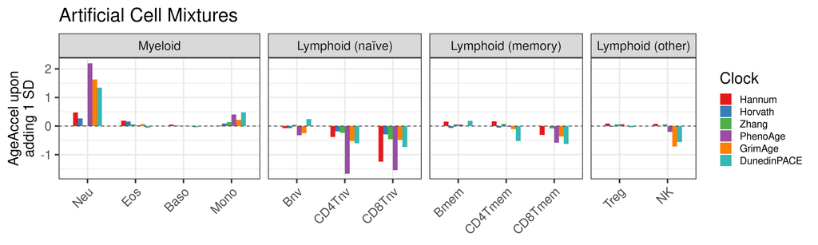

```r
ggplot(data = plot.filter, aes(x = id, y = diff, fill = variable, group = variable)) +
    scale_color_manual(values = c("#E41A1C", "#377EB8", "#4DAF4A", "#984EA3", "#FF7F00", "#37B8B2", "#F781BF")) +
    scale_fill_manual(values = c("#E41A1C", "#377EB8", "#4DAF4A", "#984EA3", "#FF7F00", "#37B8B2", "#F781BF")) +
    theme_bw(base_size = 22) +
    geom_bar(stat = "identity", width = 0.6, position = position_dodge(width = 0.6)) +
    theme(axis.text.x = element_text(angle = 45, hjust = 1),
          axis.title.y = element_text(size = 20),
          axis.title.x = element_blank(),
          legend.text = element_text(size = 14)) +
    geom_hline(yintercept = 0, color = "#444444", linetype = "dashed") +
    labs(title = "Artificial Cell Mixtures", x = "Fraction", y = "AgeAccel upon\nadding 1 SD", fill = "Clock") +
    facet_grid(cols = vars(group), scales = "free_x", space = "free_x")
```